# Predicting Excessive Enforcement Patterns in Police Behavior After Vehicles Stops in New York

Model Selection and Evaluation - GAM 2-Wheels

Gianmaria Pizzo

These `.Rmd` files represent the project submission for the course [Statistical Inference and Learning](https://www.unive.it/data/course/521944) by Professor [Cristiano Varin](https://www.unive.it/data/people/5592728) at [Ca’ Foscari University of Venice](https://www.unive.it/) for the year 2025/2026.

# 0) Environment

## 0.1) Packages

```r
requirements <- c(
  "scales", "dplyr", "tidyr", "viridis",
  "ggplot2", "patchwork", "pROC", "kableExtra", "mgcv"
)
```

The list only contains packages actually used in this notebook. Now, the loading of all packages should be immediate.

## 0.2) Functions

Here we define the helper functions used throughout model selection and evaluation, kept in one place for reuse across every model fitted below.

### 0.2.1) Data-Split Diagnostics

```r
# ==============================================================================
# 1. Train / Test Split Diagnostics
# ==============================================================================

#' @title Check Train/Test Level Proportions
#'
#' @description Tabulates one variable's level proportions separately in
#' `train` and `test` and reports the discrepancy in percentage points. Used
#' to verify that the stratified split preserved the marginal distribution of
#' key covariates.
#'
#' @param var The column name (present in both `train` and `test`) to tabulate.
#' @param label Human-readable label for the variable, stored in the output.
#'
#' @return A tibble with columns variable, level, train, test, diff_ppt.
check_prop <- function(var, label) {
  # Compute the relative frequency of each level in the training set
  tr <- prop.table(table(train[[var]]))
  # Compute the relative frequency of each level in the test set
  te <- prop.table(table(test[[var]]))
  # Create a summary table comparing train and test proportions
  tibble(
    # Variable levels
    level = names(tr),
    # Proportion in training set
    train = as.numeric(tr),
    # Proportion in test set
    test = as.numeric(te),
    # Difference in % between test and training proportions
    diff_ppt = round((as.numeric(te) - as.numeric(tr)) * 100, 2)
  ) %>%
    # Add descriptive variable name
    mutate(variable = label) %>%
    # Move variable name to first column
    relocate(variable)
}
```

### 0.2.2) Threshold and Confusion-Matrix Helpers

```r
# ==============================================================================
# 2. Threshold Selection and Confusion-Matrix Helpers
# ==============================================================================

#' @title Find the Youden-Optimal Classification Threshold
#'
#' @description Finds the probability threshold on an ROC curve that
#' maximises Youden's J statistic (sensitivity + specificity − 1), used
#' throughout as the single decision threshold for turning predicted
#' probabilities into classes.
#'
#' @param roc_obj A pROC "roc" object, as returned by pROC::roc().
#'
#' @return A numeric scalar, the optimal threshold on the probability scale.
best_thresh <- function(roc_obj) {
  pROC::coords(
    roc_obj, "best", ret = "threshold",
    best.method = "youden", quiet = TRUE
  )$threshold
}


#' @title Tally a Confusion Matrix
#'
#' @description Cross-tabulates actual vs predicted binary class labels.
#'
#' @param actual Integer/numeric vector of 0/1 true labels.
#' @param predicted Integer/numeric vector of 0/1 predicted labels.
#'
#' @return A tibble with columns Actual, Predicted, n (one row per non-empty cell).
conf_tib <- function(actual, predicted) {
  tibble(
    Actual = factor(actual, levels = c(0, 1)),
    Predicted = factor(predicted, levels = c(0, 1))
  ) %>%
    count(Actual, Predicted)
}


#' @title Plot a Confusion-Matrix Heatmap
#'
#' @description Renders conf_tib() output as a 2x2 tile plot with cell counts.
#'
#' @param actual Integer/numeric vector of 0/1 true labels.
#' @param predicted Integer/numeric vector of 0/1 predicted labels.
#' @param title Main title of the plot.
#'
#' @return A ggplot2 object.
plot_cm <- function(actual, predicted, title = "Confusion Matrix") {
  conf_tib(actual, predicted) %>%
    ggplot(aes(Predicted, Actual, fill = n)) +
    geom_tile(colour = "white") +
    geom_text(aes(label = scales::comma(n)), size = 5.5, fontface = "bold") +
    scale_fill_gradient(low = "#e8f4f8", high = "#2c7bb6", guide = "none") +
    scale_x_discrete(labels = c("0" = "No arrest", "1" = "Arrest")) +
    scale_y_discrete(labels = c("0" = "No arrest", "1" = "Arrest")) +
    labs(title = title, x = "Predicted", y = "Actual") +
    theme_minimal(base_size = 12) +
    theme(panel.grid = element_blank())
}


#' @title Compute Threshold-Dependent Classification Metrics
#'
#' @description Computes sensitivity, specificity, balanced accuracy, PPV,
#' and NPV for a fixed set of hard class predictions against the true labels.
#'
#' @param actual Integer/numeric vector of 0/1 true labels.
#' @param predicted Integer/numeric vector of 0/1 predicted labels.
#' @param pos Value in `actual`/`predicted` denoting the positive class.
#'
#' @return A named list with sensitivity, specificity, balanced_acc, ppv, npv.
class_metrics <- function(actual, predicted, pos = 1) {
  tp <- as.numeric(sum(actual == pos & predicted == pos))
  tn <- as.numeric(sum(actual != pos & predicted != pos))
  fp <- as.numeric(sum(actual != pos & predicted == pos))
  fn <- as.numeric(sum(actual == pos & predicted != pos))
  sens <- tp / (tp + fn)
  spec <- tn / (tn + fp)
  list(
    sensitivity = sens,
    specificity = spec,
    balanced_acc = (sens + spec) / 2,
    ppv = tp / (tp + fp),
    npv = tn / (tn + fn)
  )
}


# ==============================================================================
# 3. Probability-Based Evaluation Metrics
# ==============================================================================

#' @title Compute the Full Evaluation-Metrics Tibble for One Model
#'
#' @description Given predicted probabilities and true labels, computes
#' threshold-free metrics (AUC, PR-AUC, log-loss, Brier score) plus
#' threshold-dependent metrics at the Youden-optimal cut-off (sensitivity,
#' specificity, precision, F1, MCC, balanced accuracy). Returns one row per
#' call, so results from multiple models can be row-bound into a comparison
#' table.
#'
#' @param actual Integer/numeric vector of 0/1 true labels.
#' @param prob Numeric vector of predicted P(arrested = 1), same length as `actual`.
#' @param thr Classification threshold selected externally (on the training set),
#' applied here rather than recomputed from `actual`/`prob` to avoid leaking test labels.
#' @param model_name Label stored in the Model column.
#'
#' @return A one-row tibble of rounded metrics (see column names in the body).
compute_metrics <- function(actual, prob, thr, model_name = "Model") {
  valid <- !is.na(actual) & !is.na(prob)
  actual <- actual[valid]
  prob <- prob[valid]

  roc_obj <- pROC::roc(actual, prob, quiet = TRUE)
  auc_val <- as.numeric(pROC::auc(roc_obj))
  pred_cl <- as.integer(prob >= thr)

  # Confusion Matrix Metrics
  tp <- as.numeric(sum(actual == 1 & pred_cl == 1))
  tn <- as.numeric(sum(actual == 0 & pred_cl == 0))
  fp <- as.numeric(sum(actual == 0 & pred_cl == 1))
  fn <- as.numeric(sum(actual == 1 & pred_cl == 0))

  # Confusion Matrix Derived Metrics
  sens <- (
    if ((tp+fn) == 0) NA_real_
    else tp / (tp+fn)
  )
  spec <- (
    if ((tn+fp) == 0) NA_real_
    else tn / (tn+fp)
  )
  prec <- (
    if ((tp+fp) == 0) NA_real_
    else tp / (tp+fp)
  )
  f1 <- (
    if (is.na(prec) || is.na(sens) || (prec+sens) == 0) NA_real_
    else 2 * prec * sens / (prec + sens)
  )

  # MCC
  mcc_den <- sqrt(
    as.numeric(tp+fp) * as.numeric(tp+fn) *
    as.numeric(tn+fp) * as.numeric(tn+fn)
  )
  mcc_val <- (
    if (mcc_den == 0) NA_real_
    else (tp*tn - fp*fn) / mcc_den
  )

  # Logloss
  eps <- 1e-15
  logloss <- -mean(
    actual * log(pmax(prob, eps)) +
    (1-actual) * log(pmax(1-prob, eps))
  )

  # Brier Score
  brier <- mean((prob - actual)^2)

  # PR-AUC via trapezoid rule over pROC coords (pROC has no built-in PR-AUC)
  pr_raw <- pROC::coords(
    roc_obj, "all", ret = c("sensitivity", "precision"),
    transpose = FALSE, drop = FALSE
  )

  names(pr_raw)[names(pr_raw) == "sensitivity"] <- "recall"

  pr_raw <- pr_raw %>%
    filter(!is.nan(precision), !is.na(precision), !is.nan(recall)) %>%
    arrange(recall)

  pr_auc_val <- if (nrow(pr_raw) >= 2)
    sum(diff(pr_raw$recall) * (head(pr_raw$precision, -1) + tail(pr_raw$precision, -1)) / 2)
  else NA_real_

  # Print Metrics
  tibble(
    Model = model_name,
    AUC = round(auc_val, 4),
    PR_AUC = round(pr_auc_val, 4),
    Log_Loss = round(logloss, 4),
    Brier = round(brier, 4),
    Threshold = round(thr, 4),
    Sensitivity = round(sens, 3),
    Specificity = round(spec, 3),
    Precision = round(prec, 3),
    F1 = round(f1, 3),
    MCC = round(mcc_val, 3),
    Bal_Acc = round(
      if (!is.na(sens) && !is.na(spec)) (sens+spec)/2
      else NA_real_, 3
    )
  )
}
```

### 0.2.3) Model Evaluation Plot Functions

```r
# ==============================================================================
# 4. Plots for Single-Model Evaluation
# ==============================================================================

#' @title Plot the ROC Curve for a Single Model
#'
#' @description Plots sensitivity vs specificity across all thresholds, with
#' the AUC annotated on the panel.
#'
#' @param actual Integer/numeric vector of 0/1 true labels.
#' @param prob Numeric vector of predicted P(arrested = 1), same length as `actual`.
#' @param title Main title of the plot.
#'
#' @return A ggplot2 object.
plot_roc_single <- function(actual, prob, title = "ROC Curve") {
  roc_obj <- pROC::roc(actual, prob, quiet = TRUE)
  auc_lbl <- paste0("AUC = ", round(as.numeric(pROC::auc(roc_obj)), 4))
  pROC::ggroc(roc_obj, colour = "#2c7bb6", linewidth = 0.9) +
    geom_abline(slope = 1, intercept = 1, linetype = "dashed", colour = "grey60") +
    annotate("text", x = 0.25, y = 0.06, label = auc_lbl, colour = "#2c7bb6", size = 4) +
    labs(x = "Specificity", y = "Sensitivity", title = title) +
    theme_minimal(base_size = 11) + theme(panel.grid.minor = element_blank())
}
```

```r
#' @title Plot the Precision-Recall Curve for a Single Model
#'
#' @description Plots precision vs recall across all thresholds against the
#' no-skill baseline (the class prevalence), with PR-AUC annotated. More
#' informative than the ROC curve under the severe class imbalance here.
#'
#' @param actual Integer/numeric vector of 0/1 true labels.
#' @param prob Numeric vector of predicted P(arrested = 1), same length as `actual`.
#' @param title Main title of the plot.
#'
#' @return A ggplot2 object.
plot_pr_single <- function(actual, prob, title = "Precision-Recall Curve") {
  roc_obj <- pROC::roc(actual, prob, quiet = TRUE)
  pr_raw  <- pROC::coords(roc_obj, "all",
                           ret = c("sensitivity", "precision"),
                           transpose = FALSE, drop = FALSE)
  names(pr_raw)[names(pr_raw) == "sensitivity"] <- "recall"
  pr_df <- pr_raw %>%
    filter(!is.nan(precision), !is.na(precision)) %>% arrange(recall)

  # PR-AUC via trapezoid rule, same approach as in compute_metrics()
  pr_auc_lbl <- if (nrow(pr_df) >= 2) {
    v <- sum(diff(pr_df$recall) *
               (head(pr_df$precision,-1) + tail(pr_df$precision,-1)) / 2)
    paste0("PR-AUC = ", round(v, 4))
  } else "PR-AUC = NA"
  baseline <- mean(actual)
  ggplot(pr_df, aes(x = recall, y = precision)) +
    geom_line(colour = "#d73027", linewidth = 0.9) +
    geom_hline(yintercept = baseline, linetype = "dashed", colour = "grey55") +
    annotate("text", x = 0.02, y = baseline + 0.015,
             label = paste0("No-skill = ", round(baseline, 3)),
             colour = "grey40", size = 3.2, hjust = 0) +
    annotate("text", x = 0.55, y = 0.90, label = pr_auc_lbl,
             colour = "#d73027", size = 4) +
    scale_x_continuous(limits = c(0, 1)) + scale_y_continuous(limits = c(0, 1)) +
    labs(x = "Recall", y = "Precision", title = title) +
    theme_minimal(base_size = 11) + theme(panel.grid.minor = element_blank())
}
```

```r
#' @title Plot the Calibration (Reliability) Curve for a Single Model
#'
#' @description Bins predictions into `n_bins` equal-frequency groups and
#' plots mean predicted probability against observed positive rate per bin,
#' against the perfect-calibration diagonal.
#'
#' @param actual Integer/numeric vector of 0/1 true labels.
#' @param prob Numeric vector of predicted P(arrested = 1), same length as `actual`.
#' @param title Main title of the plot.
#' @param n_bins Number of quantile bins of `prob`.
#'
#' @return A ggplot2 object.
plot_calibration_single <- function(actual, prob, title = "Calibration Plot",
                                    n_bins = 10) {
  # Quantile breaks (not equal-width) so each bin has a comparable sample size
  # despite the predicted probabilities being heavily right-skewed
  brks  <- unique(quantile(prob, seq(0, 1, length.out = n_bins + 1), na.rm = TRUE))
  cal_df <- tibble(actual = actual, prob = prob) %>%
    mutate(bin = cut(prob, breaks = brks, include.lowest = TRUE)) %>%
    filter(!is.na(bin)) %>%
    group_by(bin) %>%
    summarise(mean_pred = mean(prob), mean_obs = mean(actual),
              n = n(), .groups = "drop")
  ggplot(cal_df, aes(x = mean_pred, y = mean_obs)) +
    geom_abline(slope = 1, intercept = 0, linetype = "dashed", colour = "grey55") +
    geom_line(colour = "#2c7bb6", linewidth = 0.8) +
    geom_point(aes(size = n), colour = "#2c7bb6", alpha = 0.85) +
    scale_size_continuous(name = "Count", range = c(2, 9)) +
    scale_x_continuous(labels = scales::percent_format(accuracy = 0.1)) +
    scale_y_continuous(labels = scales::percent_format(accuracy = 0.1)) +
    labs(x = "Mean predicted probability", y = "Observed positive rate",
         title = title,
         caption = "Size ∝ bin count.  Dashed = perfect calibration.") +
    theme_minimal(base_size = 11) +
    theme(legend.position = "bottom", panel.grid.minor = element_blank())
}
```

```r
#' @title Plot the Threshold-Sweep Metrics for a Single Model
#'
#' @description Plots sensitivity, specificity, precision, and F1 as
#' functions of the classification threshold, with the Youden-optimal
#' threshold marked.
#'
#' @param actual Integer/numeric vector of 0/1 true labels.
#' @param prob Numeric vector of predicted P(arrested = 1), same length as `actual`.
#' @param thr Classification threshold selected externally (on the training set).
#' @param title Main title of the plot.
#'
#' @return A ggplot2 object.
plot_threshold_single <- function(actual, prob, thr, title = "Threshold Analysis") {
  roc_obj  <- pROC::roc(actual, prob, quiet = TRUE)
  thr_data <- pROC::coords(roc_obj, "all",
                            ret = c("threshold","sensitivity","specificity","precision"),
                            transpose = FALSE, drop = FALSE) %>%
    filter(is.finite(threshold), threshold >= 0, threshold <= 1) %>%
    mutate(f1 = ifelse(!is.nan(precision) & (precision + sensitivity) > 0,
                       2 * precision * sensitivity / (precision + sensitivity), 0)) %>%
    pivot_longer(c(sensitivity, specificity, precision, f1),
                 names_to = "Metric", values_to = "Value") %>%
    mutate(Metric = recode(Metric,
      sensitivity = "Sensitivity", specificity = "Specificity",
      precision   = "Precision",   f1          = "F1 Score"))
  ggplot(thr_data, aes(x = threshold, y = Value, colour = Metric)) +
    geom_line(linewidth = 0.75, na.rm = TRUE) +
    geom_vline(xintercept = thr, linetype = "dashed",
               colour = "grey35", linewidth = 0.55) +
    annotate("text", x = thr, y = 0.04,
             label = paste0("Train-selected\n", round(thr, 3)),
             hjust = -0.08, size = 3, colour = "grey30") +
    scale_colour_viridis_d(option = "turbo", begin = 0.05, end = 0.92) +
    scale_y_continuous(limits = c(0, 1)) +
    labs(x = "Threshold", y = "Metric value", colour = NULL, title = title,
         caption = "Dashed: threshold selected on the training set") +
    theme_minimal(base_size = 11) +
    theme(legend.position = "bottom", panel.grid.minor = element_blank())
}
```

```r
#' @title Plot the 2x2 Evaluation Panel for a Single Model
#'
#' @description Composes plot_roc_single(), plot_pr_single(),
#' plot_calibration_single(), and plot_threshold_single() into one
#' (ROC | PR) / (Calibration | Threshold) patchwork layout.
#'
#' @param actual Integer/numeric vector of 0/1 true labels.
#' @param prob Numeric vector of predicted P(arrested = 1), same length as `actual`.
#' @param thr Classification threshold selected externally (on the training set).
#' @param model_name Prefixed to each sub-plot's title.
#'
#' @return A patchwork object (composed ggplot2 object).
eval_quad_plot <- function(actual, prob, thr, model_name) {
  p1 <- plot_roc_single(actual, prob,   paste(model_name, "— ROC"))
  p2 <- plot_pr_single(actual, prob,    paste(model_name, "— Precision-Recall"))
  p3 <- plot_calibration_single(actual, prob, paste(model_name, "— Calibration"))
  p4 <- plot_threshold_single(actual, prob, thr, paste(model_name, "— Threshold Analysis"))
  (p1 | p2) / (p3 | p4)
}
```

# 1) Data Loading and Preparation

```r
vehstop <- read.csv("data/vehiclestops_2_wheels_final.csv")
```

## 1.1) Factor conversion and Reference Levels

We convert all categorical predictors to factors and set interpretable reference levels before any modelling step, ensuring consistency between all downstream model fits and cross-validation folds.

```r
# Ordered weekday levels (ISO order)
wday_levels <- c("Monday", "Tuesday", "Wednesday", "Thursday", "Friday", "Saturday", "Sunday")

# Ordered time bracket levels
tbkt_levels <- c(
  "Late night (0–3)",
  "Early morning (4–7)",
  "Morning commute (8–11)",
  "Midday (12–15)",
  "Afternoon/evening (16–19)",
  "Night (20–23)"
)

# Ordered age-bracket levels
abkt_levels <- c("Under 18", "18–24", "25–34", "35–44", "45–54", "55–64", "65+", "Unknown")

vehstop <- vehstop %>%
  mutate(
    year = factor(year),
    month = factor(month, levels = 1:12),
    weekday = factor(weekday, levels = wday_levels),
    hour = factor(hour, levels = 0:23),
    time_bracket = factor(time_bracket, levels = tbkt_levels),
    area = factor(area),
    boro = factor(boro),
    sex = factor(sex),
    ethnicity = factor(ethnicity),
    age_bracket = factor(age_bracket, levels = abkt_levels)
  )

# Reference levels chosen for interpretable contrasts
vehstop$sex <- relevel(vehstop$sex, ref = "M")
vehstop$ethnicity <- relevel(vehstop$ethnicity, ref = "White")
vehstop$weekday <- relevel(vehstop$weekday, ref = "Monday")
vehstop$time_bracket <- relevel(vehstop$time_bracket, ref = "Morning commute (8–11)")
vehstop$age_bracket <- relevel(vehstop$age_bracket, ref = "25–34")

rm(wday_levels, tbkt_levels, abkt_levels)
```

## 1.2) Removing NAs from `age`

We had to exclude `age` as a predictor from the other models, since we had missing values that we labeled as `Unknown` in `age_bracket`. Here instead we want to include it so we will drop the NAs and use a smoothing curve.

```r
vehstop <- vehstop %>%
  dplyr::filter(!is.na(age))
```

> Note: This makes GAM not directly comparable with the other models because the dataset changes with respect to this filtering. Therefore, we will not just say “GAM performs better than Logistic/NB/LASSO” but we will take into account the interesting aspects that emerge.

## 1.3) Stratified Train / Test Split

For the train/test split, a **stratified sampling approach** is used to ensure that the training and test sets have comparable distributions of the outcome variable (`arrested`) and relevant contextual variables.

This is particularly important because the target variable is imbalanced, with arrested cases representing only a small proportion of all observations. Rather than stratifying only on `arrested`, the code constructs a **joint stratification variable** from `arrested`, `area`, `sex`, `ethnicity`, and `hour` using `interaction()`. Thus, each observation is assigned to a stratum corresponding to a particular combination of these variables.

Formally, the strata can be represented as

$$S_i =
(\text{arrested}_i,\text{area}_i,\text{sex}_i,\text{ethnicity}_i,\text{hour}_i),$$

where $S_i$ denotes the stratum to which observation $i$ belongs. The objective is to sample approximately 80% of observations within each stratum for the training set and retain the remaining 20% for testing:

$$P(i \in \mathcal{D}_{train} \mid S_i=s)
\approx 0.8,
\qquad
P(i \in \mathcal{D}_{test} \mid S_i=s) \approx 0.2.$$

```r
set.seed(2026)

# Joint stratum key; drop = TRUE removes empty combinations
vehstop$.strat <- interaction(
  vehstop$arrested, vehstop$area, vehstop$sex, vehstop$ethnicity, vehstop$hour,
  drop = TRUE
)

train_rows <- vehstop %>%
  dplyr::mutate(.row = row_number()) %>%
  dplyr::group_by(.strat) %>%
  dplyr::slice_sample(prop = 0.8) %>%
  dplyr::pull(.row)

train <- vehstop[ train_rows, ] %>% dplyr::select(-.strat)
test <- vehstop[-train_rows, ] %>% dplyr::select(-.strat)
vehstop <- vehstop %>% dplyr::select(-.strat)
```

In the code, `group_by(.strat) %>% slice_sample(prop = 0.8)` performs this within-stratum sampling, while the observations not selected for training form the test set. This approach aims to preserve not only the overall prevalence of the outcome,

$$P_{\text{train}}(\text{arrested}=1)
\approx P_{\text{test}}(\text{arrested}=1),$$

but also the composition of the data across geographic, demographic, and temporal characteristics. This is desirable because differences in these characteristics could otherwise introduce an unintended distributional difference between the training and test sets. The temporary `.strat` variable is removed after the split because it is used solely to define the sampling groups and is not intended to be used as a predictor in the subsequent modelling.

Finally, the verification code compares the empirical marginal distributions of `arrested`, `area`, `sex`, and `ethnicity` in the two datasets. For a variable $X$ and level $k$, the proportion in each dataset is calculated as

$$\hat{P}_{train}(X=k)
=
\frac{\sum_{i \in \mathcal{D}_{train}} \mathbb{I}(X_i=k)}
{|\mathcal{D}_{train}|},$$

and analogously for the test set. The difference is then reported in **percentage points**:

$$\Delta_k =
100\left[
\hat{P}_{test}(X=k)
-
\hat{P}_{train}(X=k)
\right].$$

Small values of $\Delta_k$ indicate that the corresponding characteristic is similarly represented in the two datasets. The final summary additionally compares the number of observations and the proportion of arrested cases in the training and test sets, providing a direct check that the intended approximately 80/20 split and the class distribution have been maintained.

```r
bind_rows(
  check_prop("arrested", "arrested"),
  check_prop("area", "area"),
  check_prop("sex", "sex"),
  check_prop("ethnicity", "ethnicity")
) %>%
  kbl(
    digits = 4,
    caption = "Proportion of each level in train vs test (diff in percentage points)",
    col.names = c("Variable", "Level", "Train", "Test", "Δ (ppt)")
  ) %>%
  kable_styling(bootstrap_options = c("striped", "hover", "condensed"), full_width = FALSE) %>%
  collapse_rows(columns = 1, valign = "top")
```

Proportion of each level in train vs test (diff in percentage points)

| Variable | Level | Train | Test | Δ (ppt) |
| --- | --- | --- | --- | --- |
| arrested | 0 | 0.9469 | 0.9376 | -0.93 |
|  | 1 | 0.0531 | 0.0624 | 0.93 |
| area | Bronx | 0.1553 | 0.1564 | 0.11 |
|  | Brooklyn | 0.2965 | 0.2947 | -0.18 |
|  | Manhattan | 0.2702 | 0.2688 | -0.14 |
|  | Queens | 0.2712 | 0.2697 | -0.15 |
|  | Staten Island | 0.0067 | 0.0104 | 0.36 |
| sex | M | 0.9605 | 0.9478 | -1.27 |
|  | F | 0.0352 | 0.0445 | 0.93 |
|  | U | 0.0042 | 0.0076 | 0.34 |
| ethnicity | White | 0.0971 | 0.0995 | 0.24 |
|  | Asian / Pacific Islander | 0.1108 | 0.1114 | 0.06 |
|  | Black | 0.2043 | 0.2038 | -0.05 |
|  | Hispanic | 0.4790 | 0.4708 | -0.82 |
|  | Other | 0.0162 | 0.0189 | 0.27 |
|  | Unknown | 0.0924 | 0.0954 | 0.30 |

```r
cat(sprintf(
  "Training set : %d rows  |  Arrested: %.2f%%\nTest set     : %d rows  |  Arrested: %.2f%%\n",
  nrow(train), 100 * mean(train$arrested),
  nrow(test),  100 * mean(test$arrested)
))
```

```
## Training set : 143566 rows  |  Arrested: 5.31%
## Test set     : 37049 rows  |  Arrested: 6.24%
```

## 1.4) Numerical Conversion

In order to be usable, `hour` and `age` must be integers, so we just add two newly converted versions of the same predictors.

```r
train <- train %>%
  mutate(
    hour_num = as.numeric(as.character(hour)),
    age_num = as.numeric(as.character(age))
  )

test <- test %>%
  mutate(
    hour_num = as.numeric(as.character(hour)),
    age_num = as.numeric(as.character(age))
  )
```

Finally, we remove unused data.

```r
# Remove vehstop, train, test for memory purposes
rm(vehstop, train_rows)
```

# 6) GAM

A Generalized Additive Model (GAM) extends a generalized linear model by allowing the effect of selected predictors to be represented through **flexible smooth functions** rather than assuming a strictly linear relationship.

For binary classification, GAMs can be formulated as an extension of logistic regression:

$$\log \left( \frac{P(\texttt{arrested} =
1 \mid X)}{1-P(\texttt{arrested} = 1 \mid X)} \right) = \beta_{0} +
\mathbf{X}\boldsymbol{\beta} + f_{1}(\text{hour}) +
f_{2}(\text{age})$$

where $\texttt{arrested} = Y \in \left\{ 0, 1 \right\}$ and each $f_j(\cdot)$ is a smooth function estimated from the data, commonly using penalized regression splines.

**Why did we choose this model?** This flexibility is useful when predictors such as age, time of day, or other continuous variables may have non-linear relationships with the probability of arrest.

## 6.1) Assumptions and Setup

### 6.1.2) New Formulation — Adding Splines for `hour` and `age`

We formulate the model as follows:

```r
f_gam <- arrested ~ year + month + weekday + s(hour_num, bs = 'cc', k = 10) + boro + sex + ethnicity + s(age_num, bs = 'cr', k = 6)
```

The specification `s(hour_num, bs = "cc", k = 10)` uses a **cyclic cubic regression spline**, which is appropriate for hour of day because the beginning and end of the 24-hour cycle are connected. In fact, the EDA showed a non-linear enforcement cycle across the day that a linear slope or fixed brackets cannot fully capture.

Similarly we use `s(age_num, bs = "cr", k = 6)`, a cubic regression spline with a relatively modest maximum basis dimension. The reason for this is that the EDA revealed a non-monotone age-arrest relationship that neither a linear slope nor an arbitrary bracket optimally represents.

All other predictors (`year`, `month`, `weekday`, `sex`, `ethnicity`, `boro`) remain factors.

## 6.2) Model Fit

We fit with `mgcv::gam` using `family = binomial` and REML smoothness selection.

```r
mod_gam <- mgcv::gam(f_gam, family = binomial, data = train, method = "REML")
```

## 6.3) Specific Analysis and Interpretation

```r
summary(mod_gam)
```

```
##
## Family: binomial
## Link function: logit
##
## Formula:
## arrested ~ year + month + weekday + s(hour_num, bs = "cc", k = 10) +
##     boro + sex + ethnicity + s(age_num, bs = "cr", k = 6)
##
## Parametric coefficients:
##                                   Estimate Std. Error z value Pr(>|z|)
## (Intercept)                       -2.96206    0.09186 -32.246  < 2e-16 ***
## year2024                           0.13463    0.03796   3.547 0.000390 ***
## year2025                           0.20897    0.03698   5.651 1.59e-08 ***
## month2                             0.03010    0.07444   0.404 0.685988
## month3                             0.10014    0.06959   1.439 0.150144
## month4                             0.14569    0.06657   2.189 0.028622 *
## month5                             0.14256    0.06558   2.174 0.029726 *
## month6                             0.13686    0.06402   2.138 0.032528 *
## month7                             0.20988    0.06284   3.340 0.000839 ***
## month8                             0.04792    0.06421   0.746 0.455479
## month9                             0.23093    0.06320   3.654 0.000258 ***
## month10                            0.14586    0.06340   2.301 0.021405 *
## month11                            0.07807    0.06642   1.175 0.239823
## month12                           -0.10869    0.07494  -1.450 0.146949
## weekdayTuesday                     0.12349    0.04968   2.486 0.012930 *
## weekdayWednesday                   0.03377    0.04881   0.692 0.489051
## weekdayThursday                   -0.01333    0.04912  -0.271 0.786068
## weekdayFriday                     -0.12903    0.05047  -2.557 0.010566 *
## weekdaySaturday                   -0.08870    0.05108  -1.737 0.082453 .
## weekdaySunday                     -0.13239    0.05218  -2.537 0.011182 *
## boroBrooklyn (North)              -0.87775    0.03968 -22.120  < 2e-16 ***
## boroBrooklyn (South)              -0.53912    0.03817 -14.126  < 2e-16 ***
## boroManhattan (North)             -1.12023    0.04476 -25.029  < 2e-16 ***
## boroManhattan (South)             -1.07262    0.05316 -20.176  < 2e-16 ***
## boroQueens (North)                -0.97966    0.03902 -25.104  < 2e-16 ***
## boroQueens (South)                -0.70645    0.04890 -14.447  < 2e-16 ***
## boroStaten Island                 -0.47393    0.13895  -3.411 0.000648 ***
## sexF                              -1.17405    0.12378  -9.485  < 2e-16 ***
## sexU                               0.08068    0.34612   0.233 0.815689
## ethnicityAsian / Pacific Islander -0.67450    0.08183  -8.243  < 2e-16 ***
## ethnicityBlack                     0.44667    0.05999   7.446 9.60e-14 ***
## ethnicityHispanic                  0.64177    0.05742  11.176  < 2e-16 ***
## ethnicityOther                    -2.56949    0.41266  -6.227 4.77e-10 ***
## ethnicityUnknown                  -1.05520    0.09930 -10.627  < 2e-16 ***
## ---
## Signif. codes:  0 '***' 0.001 '**' 0.01 '*' 0.05 '.' 0.1 ' ' 1
##
## Approximate significance of smooth terms:
##              edf Ref.df Chi.sq p-value
## s(hour_num) 7.52  8.000   1164  <2e-16 ***
## s(age_num)  4.66  4.918    108  <2e-16 ***
## ---
## Signif. codes:  0 '***' 0.001 '**' 0.01 '*' 0.05 '.' 0.1 ' ' 1
##
## R-sq.(adj) =  0.0391   Deviance explained = 9.61%
## -REML =  27023  Scale est. = 1         n = 143566
```

The GAM achieves $R^2_{adj} = 0.0391$ and explains approximately $9.61\%$ of the deviance in post-stop arrest outcomes in New York during 2023–2025.

In other words:

- The adjusted $R^2$ indicates that the **model has relatively low explanatory power**: only a small proportion of the variability in the observed arrest outcome is accounted for by the included predictors.
- However, in this context, the **deviance explained is the more informative measure of model fit**: the model reduces the unexplained deviance by approximately $9.61\%$ relative to an intercept-only model.

The model summary also indicates that there are nonlinear effects for `hour_num` and `age_num` (we will see later).

### 6.3.1) Coefficients

#### 6.3.1.1) General Interpretation

The fitted GAM models the conditional probability of arrest using a binomial distribution with a logit link.

All parametric coefficients are expressed on the **log-odds scale**.

Exponentiating a coefficient gives the corresponding **odds ratio (OR)** $OR=e^\beta$. An $OR>1$ indicates higher odds of arrest relative to the reference category, while $OR<1$ indicates lower odds, holding all other variables constant.

#### 6.3.1.2) Specific Interpretation — Coefficients

The **intercept** is $-2.962$, corresponding to baseline odds of $e^{-2.962}\approx0.052$, or a probability of approximately $4.9\%$.

- However, the intercept should not be interpreted as the unconditional arrest rate. It refers to an **observation belonging to all categorical reference groups while the centered smooth effects are equal to zero**.

For the remaining coefficients, interpretations are conditional on all other predictors in the model.

Let us see the significant (at $5\%$) *time-related* coefficients first.

| Effect | Estimate | OR | Interpretation |
| --- | --- | --- | --- |
| `year2024` | 0.135 | 1.144 | Approximately **14% higher odds** of arrest than 2023 |
| `year2025` | 0.209 | 1.232 | Approximately **23% higher odds** than 2023 |
| `month4` | 0.146 | 1.157 | April has approximately **16% higher odds** than January |
| `month5` | 0.143 | 1.153 | May has approximately **15% higher odds** than January |
| `month6` | 0.137 | 1.147 | June has approximately **15% higher odds** than January |
| `month7` | 0.210 | 1.234 | July has approximately **23% higher odds** than January |
| `month9` | 0.231 | 1.260 | September has approximately **26% higher odds** than January |
| `month10` | 0.146 | 1.157 | October has approximately **16% higher odds** than January |
| `weekdayTuesday` | 0.123 | 1.131 | Tuesday has approximately **13% higher odds** than Monday |
| `weekdayFriday` | -0.129 | 0.879 | Friday has approximately **12% lower odds** than Monday |
| `weekdaySunday` | -0.132 | 0.876 | Sunday has approximately **12% lower odds** than Monday |

As it is easy to see, there are other month and weekday coefficients but they are not “statistically different from their corresponding reference categories at the conventional $5\%$ level”.

In particular,

- February, March, August, November and December do not differ significantly from January;
- Wednesday and Thursday similarly do not differ significantly from Monday, while Saturday shows weak evidence ($p=0.082$).

The coefficients from `boro` are all statistically significant at the same level:

| Borough category | Estimate | OR | Relative odds |
| --- | --- | --- | --- |
| Brooklyn (North) | -0.878 | 0.416 | **58% lower** |
| Brooklyn (South) | -0.539 | 0.583 | **42% lower** |
| Manhattan (North) | -1.120 | 0.326 | **67% lower** |
| Manhattan (South) | -1.073 | 0.342 | **66% lower** |
| Queens (North) | -0.980 | 0.375 | **63% lower** |
| Queens (South) | -0.706 | 0.493 | **51% lower** |
| Staten Island | -0.474 | 0.623 | **38% lower** |

Plus, each coefficient has significantly lower conditional odds of arrest than the borough reference category (`Bronx`). These effects are **some of the strongest parametric associations** in the model.

For what regards `sex`’s coefficients

- We have a great association for `sexF`, $e^{-1.174}=0.309$. This means, the related observations have approximately **69% lower odds of arrest** than the reference sex category (`sexM`), fixing the remaining predictors;
- However, the coefficient for `sexU` is small and non-significant ($p=0.816$). In other words, we see no evidence of a difference from the reference category.

`ethnicity` also shows substantial conditional differences:

| Ethnicity | Estimate | OR | Relative odds |
| --- | --- | --- | --- |
| Asian / Pacific Islander | -0.675 | 0.509 | **49% lower** |
| Black | 0.447 | 1.563 | **56% higher** |
| Hispanic | 0.642 | 1.900 | **90% higher** |
| Other | -2.569 | 0.077 | **92% lower** |
| Unknown | -1.055 | 0.348 | **65% lower** |

These comparisons are all relative to `White`.

For example (holding the other variables constant) the estimated odds of arrest for observations categorized as `Hispanic` are around **1.90 times** those of `White`. Instead, `Asian / Pacific Islander` have approximately half the odds.

*We move the discussion of smooth effects to the next section*.

### 6.3.2) Smooth Term and Plots

[figure not shown]

```r
par(mfrow = c(1, 2), mar = c(4, 4, 2.5, 1))
plot(mod_gam, shade = TRUE, shade.col = "lightblue", seWithMean = TRUE,
     pages = 0, scale = 0)
```

```r
par(mfrow = c(1, 1))
```

These plots now allow a much more specific interpretation of the two smooth terms than the GAM summary alone.

#### 6.3.2.1) General Interpretation

First of all we focus on **EDF** or Estimated Degrees of Freedom. They tell us **how complex the fitted smooth actually is after penalization and gives us indication about the linearity**.

- $EDF \approx 1$ would indicate an approximately linear effect or relationship.
- $EDF >> 1$ instead indicates evidence of a **non-linear relationship**.

Then, we have a value for $\chi^{2}$. This tests **whether the smooth term** **contributes to explaining the variance in the response after fixing the other terms in the model**.

- The null hypothesis is $H_{0} : f_{j}(x) = 0$ meaning that the predictor has no meaningful contribution to the linear predictor once the other variables are accounted for.

Finally, the **p-value** indicates how strong is the evidence that the smooth terms **are associated with the conditional probability of arrest (or whether the smooth contributes to the model)**, after fixing the other predictors.

For what concerns the plot, the **vertical axis** is the estimated **partial effect on the log-odds of arrest** (after fixing the remaining predictors and smooth terms). Instead, the horizontal axis follows the numerical range of values for the term.

The smooths are centered around zero, so:

- Regions where $f(x)>0$ indicates higher conditional log-odds of arrest relative to the model’s average smooth effect (baseline), while
- $f(x)<0$ indicates lower conditional log-odds.

#### 6.3.2.2) Focus: Smooth effect of hour

The smooth term for `hour` is statistically significant:

$$\text{edf}=7.52,\qquad
\chi^2=1164,\qquad p<2\times10^{-16}.$$

This provides very strong evidence that **time of day is associated with arrest probability after controlling for the other predictors**. In other words, the hourly pattern matters.

Furthermore, its **effect is strongly non-linear** ($\text{edf}=7.52 >> 1,\ p<2\times10^{-16}$).

Since the significance test is not enough to indicate which particular hours have the highest or lowest arrest probabilities, we look again at the picture.

The estimated arrest propensity (or “conditional log-odds of arrest relative to the model’s average smooth effect”)

1. Is **relatively high** during the **late-night/very early morning**. In fact, we can see that from around 8 PM to 3 AM we have $> 0.5$, with a peak at **1-2 AM**;
2. Then, it decreases during the early morning from approximately **4 AM onward** and finds its minimum around **7–8 AM**;
3. After approximately 8 AM, the smooth rises rapidly and after around 12 PM it gradually increases through the afternoon and evening;
4. By the **late evening (approximately 8 PM - 11 PM)**, it is clearly elevated.

Thus, the model provides further evidence towards the hypothesis we made during the EDA.

The fitted smooth $f_{\text{hour}}$ covers around $2.3$ log-odds units between its minimum and maximum. This corresponds to $\approx 10 \times$ difference/change in estimated arrest odds between the corresponding hours, conditional on the other variables in the model.

#### 6.3.2.3) Focus: Smooth effect of age

Age also has a highly significant smooth effect:

$$\text{edf}=4.66,\qquad
\chi^2=108,\qquad
p<2\times10^{-16}.$$

Thus, there is **strong evidence that arrest probability varies with age** after fixing the remaining predictors.

Again, $\text{edf}=4.66,\ p<2\times10^{-16}$ indicates that the relationship is meaningfully **non-linear** and statistically significant (although its variation is smaller than `hour`).

The curve indicates **relatively elevated conditional arrest propensity** among the **youngest drivers**. Then, we observe a local minimum at approximately **28–30 years**. From roughly **30-50 years** the age effect is close to zero. Finally, the curve rises to a local maximum at **60–62 years**, before a big decline for **65–70 years** (which have wider confidence intervals indicating uncertainty, consistent with the number of observations).

## 6.4) Evaluation on Test Set

```r
# Select threshold on training data
prob_gam_train <- predict(mod_gam, newdata = train, type = "response")
roc_gam_train <- pROC::roc(train$arrested, prob_gam_train, quiet = TRUE)
thr_gam <- best_thresh(roc_gam_train)

prob_gam <- predict(mod_gam, newdata = test, type = "response")
roc_gam <- pROC::roc(test$arrested, prob_gam, quiet = TRUE)
auc_gam <- as.numeric(pROC::auc(roc_gam))
class_gam <- as.integer(prob_gam >= thr_gam)
met_gam <- class_metrics(test$arrested, class_gam)
```

### 6.4.1) Confusion Matrix

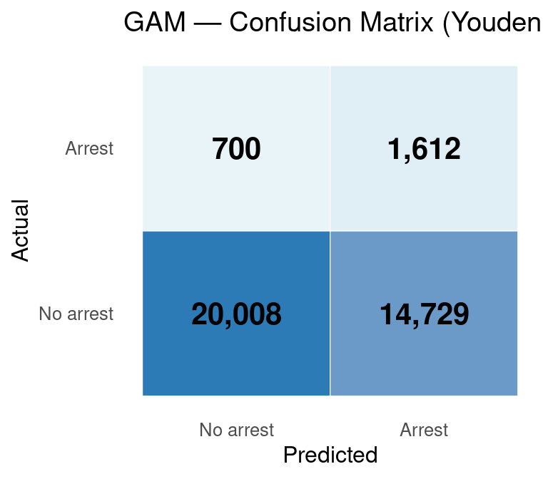

```r
plot_cm(test$arrested, class_gam, title = "GAM — Confusion Matrix (Youden threshold, train-selected)")
```

```r
cat(sprintf(
  "AUC: %.4f  |  Threshold (Youden, train-selected): %.4f\nSensitivity: %.3f  |  Specificity: %.3f  |  Balanced accuracy: %.3f\n",
  auc_gam, thr_gam, met_gam$sensitivity, met_gam$specificity, met_gam$balanced_acc
))
```

```
## AUC: 0.6897  |  Threshold (Youden, train-selected): 0.0483
## Sensitivity: 0.697  |  Specificity: 0.576  |  Balanced accuracy: 0.637
```

The confusion matrix shows

- **1,612 true positives**;
- **700 false negatives**;
- **20,008 true negatives**;
- And **14,729 false positives**.

The model therefore detects most arrests, but generates a substantial number of false alarms. Of the 2,312 actual arrests, 1,612 are correctly identified and 700 are missed. Among non-arrests, 20,008 are correctly rejected while 14,729 are incorrectly predicted as arrests.

The Youden threshold is **0.0483**, approximately 0.048 in the threshold plot and well below the 0.5 cutoff. This value is selected by maximising Youden’s $J$ on the training-set ROC curve, then frozen and applied unchanged to the test set below, so no test-set information enters the cutoff choice.

Moreover, the **AUC of 0.6897** indicates **modest discriminatory ability**: the GAM performs better than random classification, but separation between arrests and non-arrests remains limited.

Now for the derived metrics:

| Metric | Value | Interpretation |
| --- | --- | --- |
| Accuracy | 0.584 | About 58.4% of all test observations are correctly classified, but accuracy alone is not very informative because of class imbalance |
| Sensitivity / Recall | 0.697 | About 69.7% of actual arrests are correctly detected |
| Specificity | 0.576 | About 57.6% of non-arrests are correctly identified |
| Precision | 0.099 | Only about 9.9% of predicted arrests correspond to actual arrests |
| F1 | 0.173 | Low harmonic mean of precision and recall, mainly limited by low precision |
| Balanced Accuracy | 0.637 | Moderate ability to distinguish the two classes when they receive equal weight |

### 6.4.2) Performance Analysis

This was partly covered in the previous section, so here we will be focusing on the metrics that we have yet to mention.

```r
compute_metrics(test$arrested, prob_gam, thr_gam, "GAM") %>%
  kbl(
    caption   = "GAM — full evaluation metrics (test set; Youden threshold selected on training set)",
    col.names = c("Model","AUC","PR-AUC","Log-Loss","Brier",
                  "Threshold","Sensitivity","Specificity","Precision","F1","MCC","Bal. Acc.")
  ) %>%
  kable_styling(bootstrap_options = c("striped","condensed"), full_width = TRUE)
```

GAM — full evaluation metrics (test set; Youden threshold selected on training set)

| Model | AUC | PR-AUC | Log-Loss | Brier | Threshold | Sensitivity | Specificity | Precision | F1 | MCC | Bal. Acc. |
| --- | --- | --- | --- | --- | --- | --- | --- | --- | --- | --- | --- |
| GAM | 0.6897 | 0.1247 | 0.2235 | 0.057 | 0.0483 | 0.697 | 0.576 | 0.099 | 0.173 | 0.133 | 0.637 |

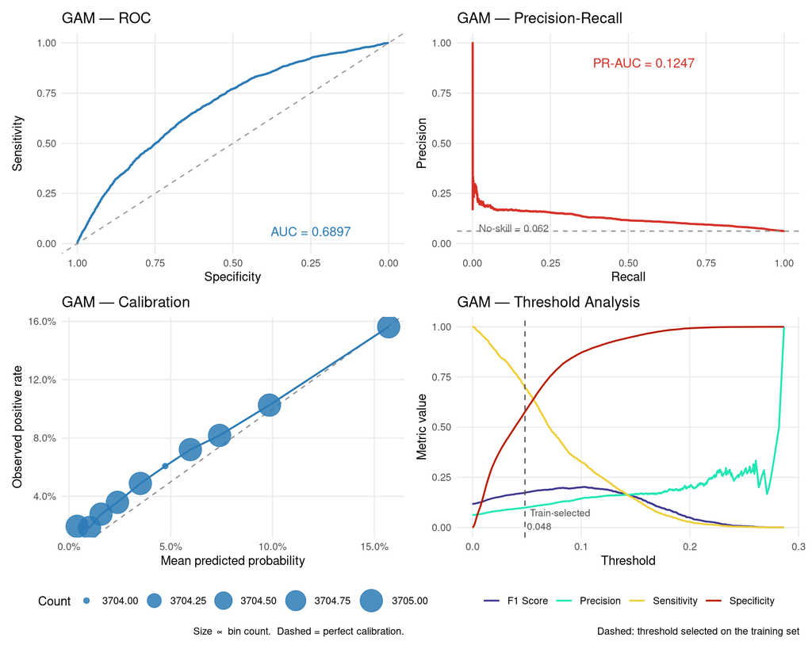

```r
eval_quad_plot(test$arrested, prob_gam, thr_gam, "GAM")
```

#### 6.4.2.1) Overall performance

| Metric | Value | Interpretation |
| --- | --- | --- |
| **AUC** | 0.6897 | Moderate discrimination between arrests and non-arrests |
| **PR-AUC** | 0.1247 | Above the no-skill baseline of $\approx 0.062$, but still low in absolute terms |
| **Log-Loss** | 0.2235 | Predicted probabilities contain useful information, though improvement over a prevalence-only model is modest |
| **Brier** | 0.0570 | Reasonably accurate probability estimates and slightly better than the prevalence-only baseline |
| Threshold | 0.0483 | Low cutoff, selected on the training set via Youden’s criterion and then applied unchanged to the test set |
| **MCC** | 0.133 | Weak positive association between predicted and observed classes |
| Balanced Accuracy | 0.637 | Moderate performance when both classes are weighted equally |

The main conclusion is that the GAM captures **meaningful but limited predictive signal**. It performs better than chance and produces probabilities that are generally close to the calibration diagonal, but its **ability to make precise positive classifications is still weak** because arrests are a rare class.

#### 6.4.2.2) AUC

The test-set AUC is $\approx 0.690$.

This means that if we randomly select (i) one observation where an arrest occurred, and (ii) one observation where an arrest did not occur, the model assigns a higher predicted probability to the arrest observation about 69% of the time.

The ROC curve **remains above the main diagonal**, indicating that the model contains useful ranking information. However, the AUC also shows that separation between the two classes remains limited, with substantial overlap between their predicted probabilities.

#### 6.4.2.3) PR-AUC

This is particularly important given our imbalanced outcome.

Our positive class is rare, so ROC-AUC can sometimes give an overly optimistic impression of performance. **Precision-Recall AUC focuses directly on the positive class**, considering the trade-off between precision and recall.

Here, we obtain:

$$\text{PR-AUC}=0.1247$$

The baseline PR-AUC is approximately equal to the positive-class prevalence:

$$\text{PR-AUC}_{\text{baseline}}\approx0.062$$

*But how good is* $0.1247$? It is clearly above the no-skill baseline, indicating that the **GAM provides useful information for ranking observations in the minority class**. However, the absolute PR-AUC remains low because of the strong class imbalance, and precision is still limited.

#### 6.4.2.4) Log-Loss

> Log-loss evaluates the **quality of the predicted probabilities**, rather than simply stating whether the final classification is correct.

This measure cares about **how confident the model is**. In our case:

$$\text{Log-Loss}=0.2235$$

In order to give some more context, a simple model assigning to every observation the test-set arrest prevalence of approximately $6.2\%$ would obtain a log-loss of about $0.234$.

The GAM **improves on this simple baseline, although very little**. Its probability estimates contain useful information, but a considerable amount of uncertainty in the outcome remains unexplained.

#### 6.4.2.5) Brier Score

The Brier score is useful here because it evaluates whether the predicted probabilities are close to the observed outcomes, rather than merely whether the model ranks observations correctly.

> Formally, the Brier score measures the squared error of the predicted probabilities (the lower, the better).

For the GAM,

$$\text{Brier}=0.0570$$

A baseline model would obtain approximately

$$0.0585$$

so the GAM performs just slightly better.

#### 6.4.2.6) MCC

The **Matthews Correlation Coefficient (MCC)** is particularly useful for imbalanced classification because it incorporates all four components of the confusion matrix:

$$MCC =
\frac{TP\cdot TN-FP\cdot FN}
{\sqrt{(TP+FP)(TP+FN)(TN+FP)(TN+FN)}}
\in [-1,1]$$

where:

- $1$ = perfect prediction
- $0$ = no association between predictions and outcomes
- $-1$ = completely incorrect prediction

Our result is:

$$MCC=0.133$$

Thus, there is a **positive but weak association between predictions and actual outcomes** (consistent with CM). Simply put:

- The model is doing meaningfully better than random classification;
- But that its classification performance is very limited.

#### 6.4.2.7) Thresholds

The classification threshold selected using **Youden’s index** is

$$t^*=0.0483$$

This threshold is selected once by maximising Youden’s $J$ on the training-set ROC curve, then frozen and applied unchanged to the test set, so no test-set information is used in choosing the cutoff.

The threshold analysis also shows the expected trade-off: lowering the threshold increases sensitivity but reduces specificity, while increasing it improves specificity at the cost of missing more arrests.

Thus, approximately **69.7% of actual arrests are detected**, but this comes at the cost of many false-positive arrest predictions. The low threshold reflects the rarity of the positive class and increases sensitivity relative to the conventional $0.5$ cutoff.

#### 6.4.2.8) Final Remarks

Let us put the metrics together:

- **Discrimination**, $\text{AUC} \approx 0.690$: the GAM has moderate ability to rank arrests above non-arrests;
- **Rare-class performance**, $\text{PR-AUC} \approx 0.125$: clearly better than the $\approx0.062$ no-skill baseline, but positive-class identification remains difficult;
- **Probability predictions**, $\text{Brier} \approx 0.057,\; \text{LogLoss} \approx 0.224$: probabilities are reasonably calibrated and improve modestly over a prevalence-only model;
- **Classification**, $\text{MCC} \approx 0.133$: binary predictions show only a weak association with the true outcomes;
- **Class balance**, $\text{ACC}_{\text{Balanced}} \approx 0.637$: sensitivity and specificity are reasonably balanced, but overall classification performance remains moderate.

Now for the final conclusions:

- The GAM captures a **real but limited predictive signal** in the available demographic, temporal, and geographical variables.
- Its strongest result is its ability to **rank observations by relative arrest risk**, rather than to produce highly accurate binary classifications.
- The low positive-class prevalence strongly affects precision: obtaining a sensitivity of $0.697$ requires accepting a substantial number of false positives.
- The probability estimates appear more useful than the thresholded classifications, particularly given the reasonably good calibration.
- Consequently, the GAM is best interpreted as a model of **relative arrest propensity and estimated probability**, rather than as a highly accurate classifier of individual arrests.

## 6.5) GAM — Smoothness Diagnostics (gam.check)

The `mgcv::gam.check()` produces four residual plots (QQplot, residuals vs fitted, histogram of residuals, response vs fitted values) and tests whether the basis dimension $k$ is sufficient for each smooth term.

Note that for a binomial GAM, these diagnostic plots need to be interpreted differently from the familiar residual diagnostics of gaussian linear regression. In particular, deviance residuals are not expected to be normally distributed because the response is binary.

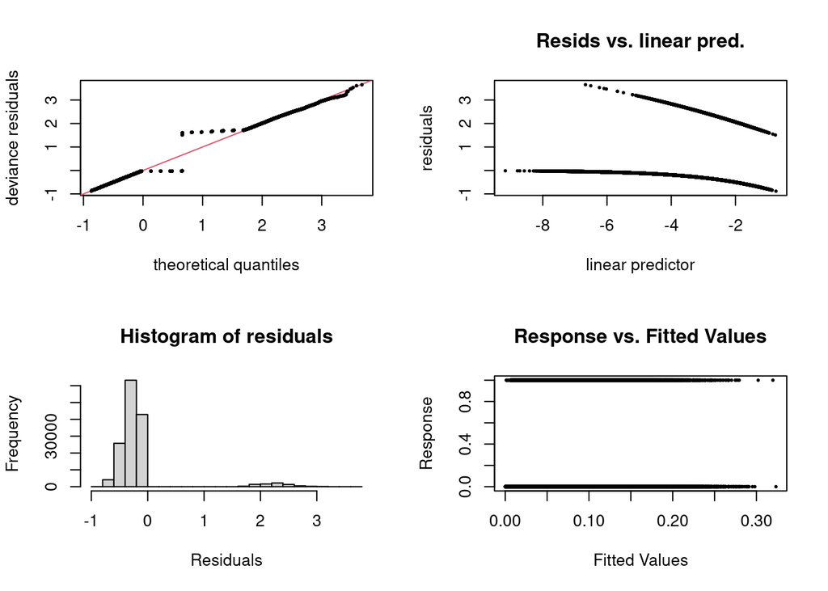

```
##
## Method: REML   Optimizer: outer newton
## full convergence after 6 iterations.
## Gradient range [3.172787e-09,0.0001131974]
## (score 27022.69 & scale 1).
## Hessian positive definite, eigenvalue range [1.114928,3.513423].
## Model rank =  47 / 47
##
## Basis dimension (k) checking results. Low p-value (k-index<1) may
## indicate that k is too low, especially if edf is close to k'.
##
##               k'  edf k-index p-value
## s(hour_num) 8.00 7.52    0.92    0.66
## s(age_num)  5.00 4.66    0.92    0.58
```

```r
par(mfrow = c(2, 2))
mgcv::gam.check(mod_gam, pch = 19, cex = 0.3)
```

Overall, the four plots do not reveal a clear diagnostic failure. Much of their unusual appearance is an expected consequence of fitting a **binomial GAM to a strongly imbalanced binary response**.

### 3.5.1) QQplot

The stepped/clumped structure is a consequence of the `0/1` response and the imbalance. The upper positive residuals correspond mainly to observations with `arrested = 1` that received relatively low predicted probabilities.

The Q-Q plot indicates a strongly non-Gaussian residual distribution, but this is **expected in this setting and is not by itself evidence of model misspecification**.

### 3.5.2) Residuals vs. linear predictor

The residuals form two clearly separated bands. This is also typical of a binary model:

- The lower band corresponds to observations with `arrested = 0`,
- The upper band corresponds to observations with `arrested = 1`.

Positive observations tend to have relatively large positive residuals because arrests are rare and the fitted probabilities are generally low. On the other hand non-arrests mostly have small negative residuals.

There is no irregular cloud or unexpected structure beyond that induced by the binary response. In other words, the pattern reflects the **rare-event nature of the outcome rather than a heteroscedasticity problem**.

### 3.5.3) Histogram of residuals

The residual distribution is highly asymmetric:

- Most residuals are concentrated just below zero, and they correspond to the majority of correctly predicted non-arrest observations.
- A much smaller group is found at positive residual values. These correspond to actual arrests for which the model assigned relatively low probabilities.

This shape is consistent with the strong class imbalance.

### 3.5.4) Response vs. fitted values

Because the response is binary, observations necessarily appear on two horizontal lines at $Y=0$ and $Y=1$.

- Most fitted probabilities are relatively small, which is consistent with the nature of the response.
- There is considerable overlap in predicted probabilities between arrests and non-arrests. In particular, many actual arrests still receive relatively low fitted probabilities.

This is consistent with the model’s previously observed **moderate discrimination rather than strong class separation**.